# Visualization

Thijs Janzen

# Visualization

The GenomeAdmixR package provides many different visualization options, here we will explore a variety of them. First, we simulate a scenario with selection, to obtain somewhat meaningful results.

```r
select_matrix <- matrix(nrow = 1, ncol = 5)
select_matrix[1, ] <- c(0.5, 1, 1 + 0.05, 1 + 0.1, 0)
population <- simulate_admixture(
                      module = ancestry_module(markers =
                                                c(0.5,
                                                 seq(0, 1, length.out = 100))),
                                pop_size = 1000,
                                 total_runtime = 200,
                                 select_matrix = select_matrix)
```

```
## Found a selection matrix, performing simulation including selection
```

Now, we can first view whether selection on our marker has yielded an increase in frequency:

## Plot over time

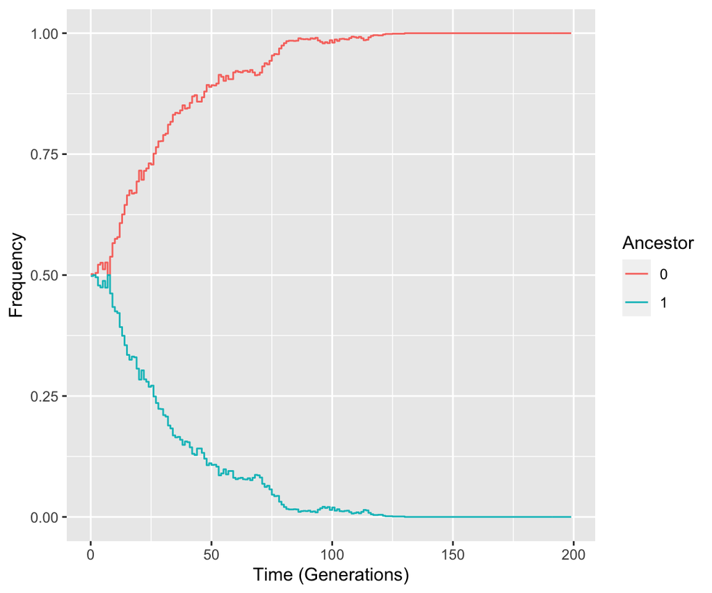

```r
plot_over_time(population$frequencies, focal_location = 0.500)
```

Indeed, we observe that over time the frequency of the allele under selection (0) increases to fixation due to selection.

## Plot Frequencies

How are the alleles scattered across the genome? we can answer that with the function plot_frequencies:

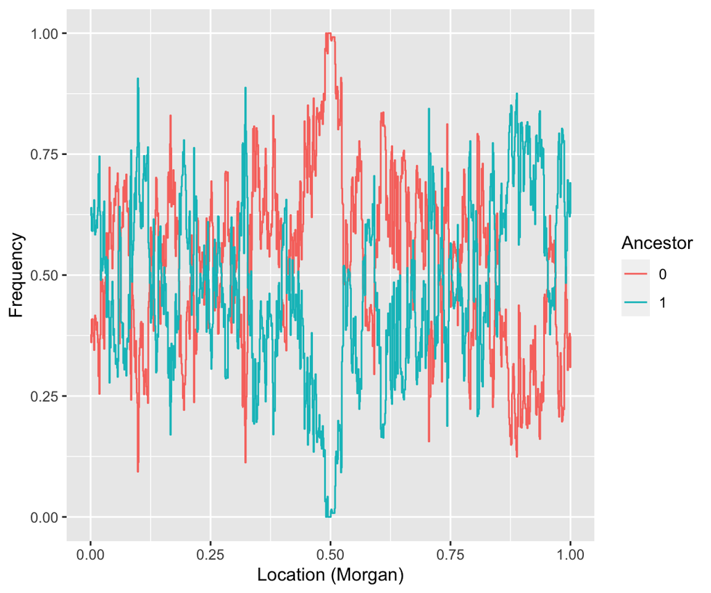

```r
plot_frequencies(population, locations = seq(0, 1, length.out = 1000))
```

As expected, we observe a huge increase around the location of the marker under selection (at 0.5 Morgan).

## plot difference frequencies

If instead, we are interested in the change in frequency of a marker, we can do so using plot_difference_frequencies.

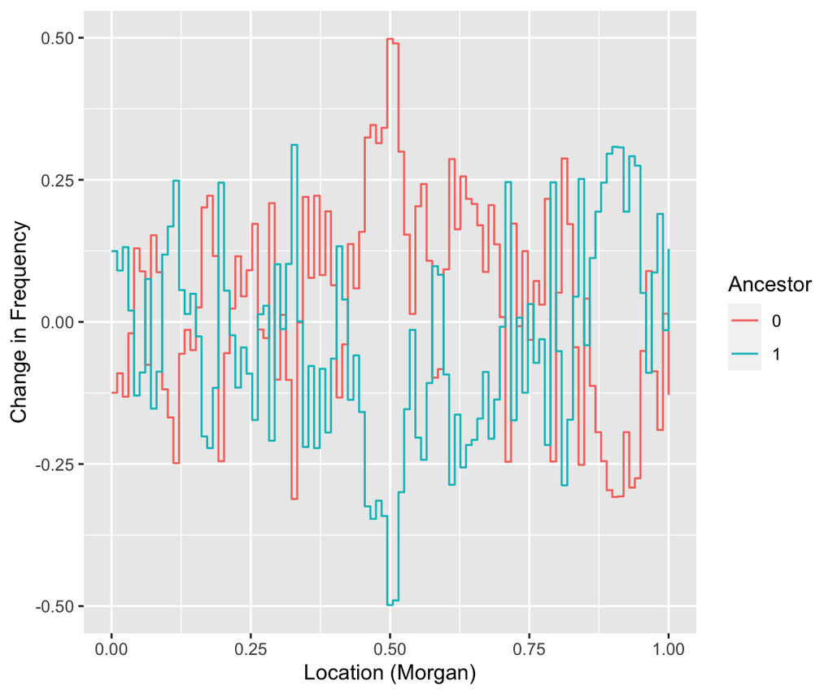

```r
plot_difference_frequencies(population)
```

## plot_start_end

Visualized in another way, plot_start_end plots the frequency distributions at the start and at the end of the simulation:

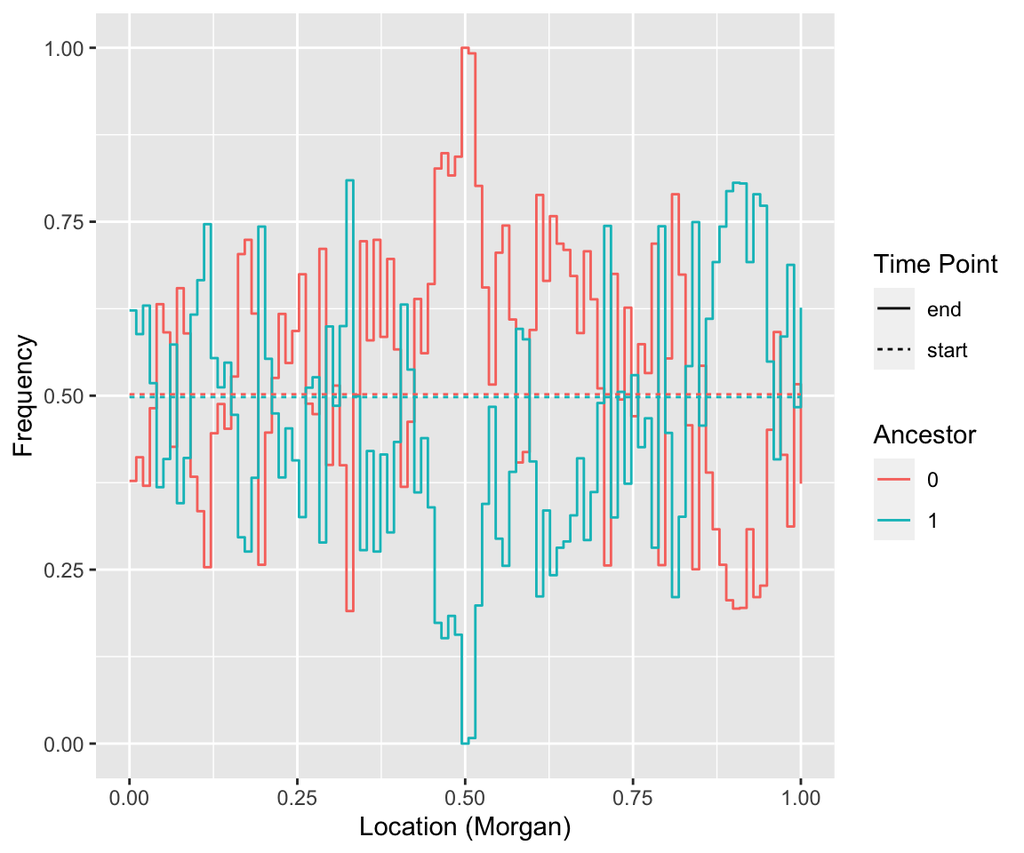

```r
plot_start_end(population)
```

## joyplots

If, indeed, we are more interested in the progression over time, we can also consult a so called ‘joyplot’, or ‘ridgeplot’:

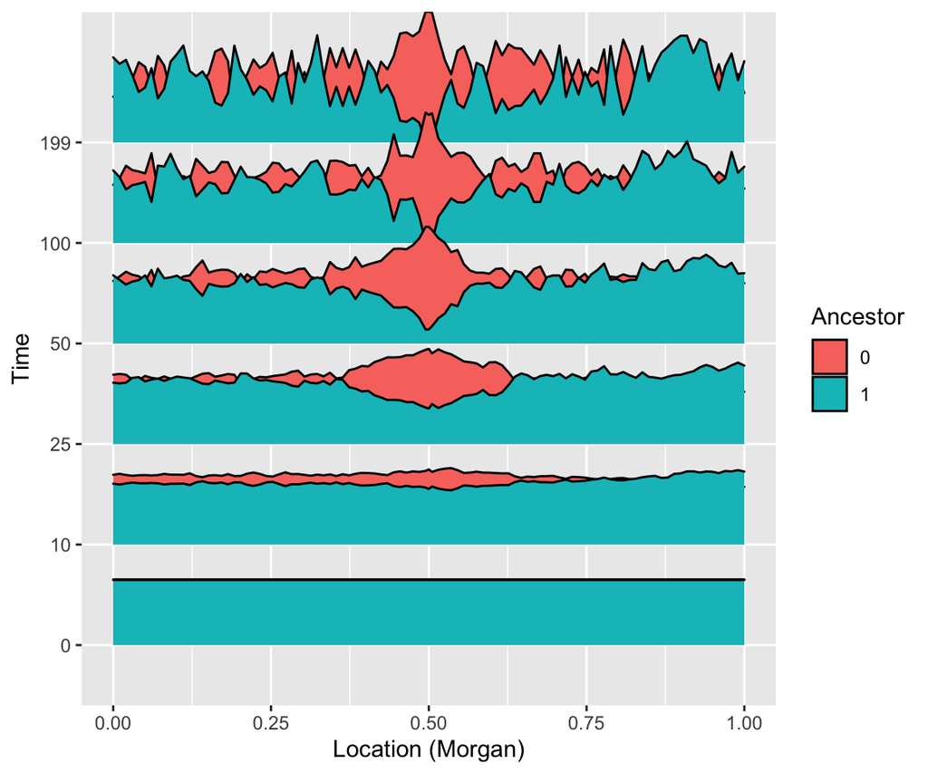

```r
plot_joyplot_frequencies(population$frequencies,
                         time_points = c(0, 10, 25, 50, 100, 199))
```

## Plotting individual chromosomes

Lastly, individual chromosomes can be visualized using the standard plotting functions, where both the entire chromosome, and a fraction of the chromosome, can be visualized:

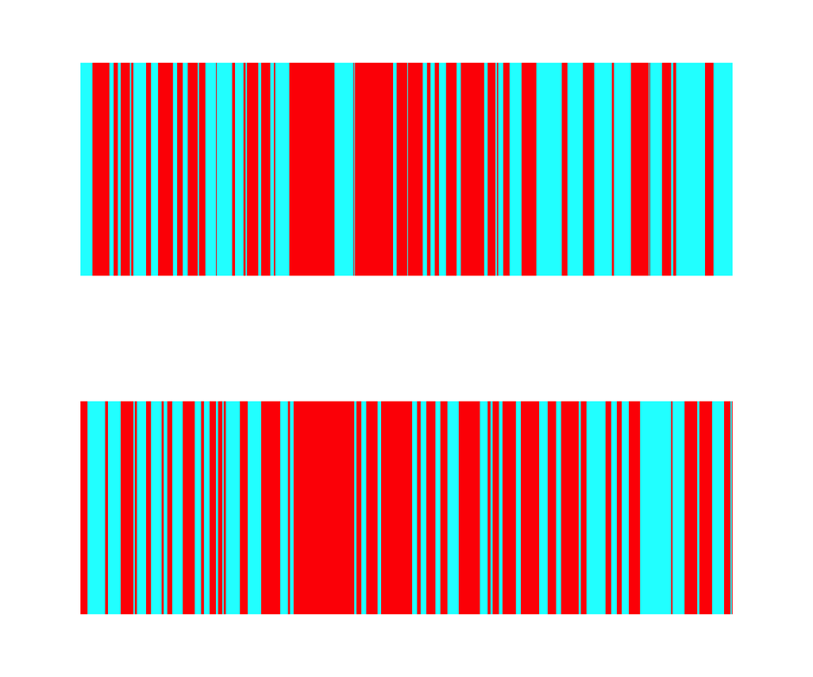

```r
plot(population$population[[1]])
```

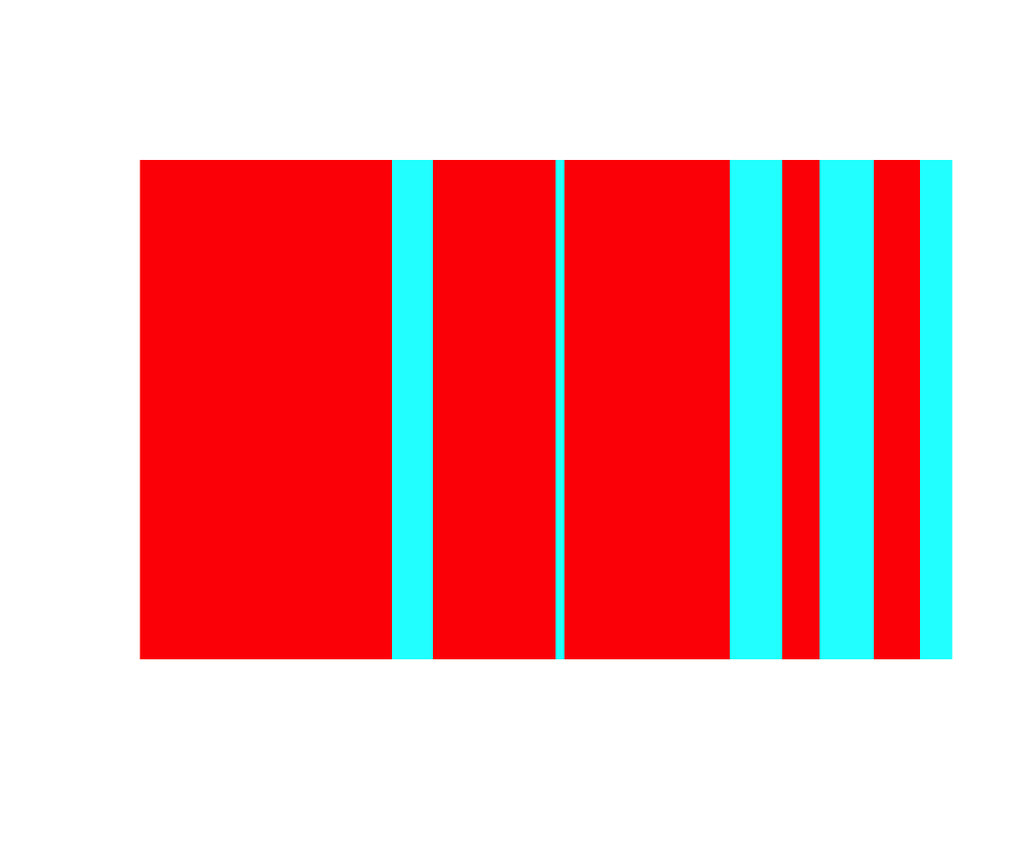

```r
plot_chromosome(population$population[[1]]$chromosome1,
                xmin = 0.45, xmax = 0.55)
```